# Three-Way Equity Classifier Comparison

GICS Sectors vs. SIC/FF12 Industries vs. K-Means Co-Movement Clusters

Author

Group 8 | University of South Florida

Published

April 27, 2026

# Executive summary

This project asks whether data-driven groupings of S&P 500 stocks classify firms more coherently than the GICS industry standard, and whether one grouping scheme produces better return-anomaly signals than another. We compare three classification systems head-to-head:

1. **GICS sectors** — the eleven Global Industry Classification Standard sectors that the index providers use.
2. **SIC-based FF12 industries** — Ken French’s twelve-industry partition, which is built directly from SIC codes and is the academic-finance counterpart to GICS.
3. **K-Means clusters on return co-movement** — an unsupervised partition that groups stocks whose monthly excess returns move together over a rolling sixty-month window, refit annually with label matching.

All three schemes are fed through the same downstream pipeline on the same data, and we compare them on four dimensions: composition overlap, within-group homogeneity, predictive accuracy on one-month-forward alpha, and anomaly-detection behaviour.

Two design choices, made in response to feedback on an earlier draft of this project, deserve to be flagged at the top:

- **The target is alpha, not raw return.** Predicting realised return from factor exposures would mostly recover the standard risk premia (high-beta stocks earn higher returns on average) — a tautology, not a finding. The economically interesting quantity is the residual after factor exposure is priced out, i.e. realised alpha. We predict $\alpha_{i,t+1}$ throughout.
- **FF factors enter as features only with a publication lag.** Ken French’s data library publishes FF5 with a multi-month delay, so a forecast that consumes contemporaneous FF values would be unusable in real time. Every feature derived from FF returns is lagged by 2 months. (Realised alpha at month $t$ is computed from $F_t$, but it is a *label* — never a feature input — so this is internally consistent.)

The dataset and pipeline are built with the dev-mode toggle in `CFG`. The HTML version of this report renders to the full S&P 500 universe when `CFG$dev_mode <- FALSE`; we leave dev mode on here for reproducibility on modest hardware. Numbers and figures will tighten when run on the full universe.

# 1. Research question

Do data-driven groupings of S&P 500 stocks classify firms more coherently than GICS sectors, and do they better surface forward-alpha anomalies?

This restates the question we posed in the original project blueprint in two ways. First, we no longer compare an industry classification (GICS) to a *risk* taxonomy (FF5 loadings), because those are incommensurable. The right comparison set for an industry classification is other industry classifications — GICS, SIC/FF12, and an unsupervised industry-style clustering. Second, we judge “better classification” not just on predictive R² but also on within-group homogeneity (do members really behave alike?) and on anomaly-flagging quality (do flagged outliers subsequently earn different forward alpha?).

# 2. Methods

## 2.1 The three classification schemes

**GICS sectors.** Eleven sectors assigned per stock-month via the CRSP/Compustat Merged (CCM) linkage. Membership is point-in-time: a stock that switches sectors mid-sample carries the new sector going forward.

**SIC/FF12.** Each stock-month’s SIC code (from CRSP `stocknames`, respecting historical name ranges) is mapped to one of twelve Ken French industries. SIC codes that fall outside any range get assigned to “Other.”

**K-Means clusters on return co-movement.** At the end of each calendar year, we take the prior sixty months of monthly excess returns. For each stock with at least thirty-six valid months we form a feature vector equal to that stock’s column of the cross-sectional correlation matrix — i.e. each stock is described by its correlation with every other stock in the panel. We reduce to ten principal components and fit K-Means for $k \in \{2, \ldots, 10\}$, picking $k$ that maximises the mean silhouette. The fitted assignment is used for all twelve months of the following calendar year. Cluster identities are kept stable across refits by Hungarian-algorithm matching against the previous fit’s labels.

## 2.2 Target: realised alpha

For each stock-month we compute realised alpha as the residual from the five-factor model:
$$\alpha_{i,t} \;=\; r^e_{i,t} \;-\; \sum_{k \in \{\text{Mkt},\text{SMB},\text{HML},\text{RMW},\text{CMA}\}} \hat\beta_{i,k}\, F_{k,t},$$
where $r^e_{i,t}$ is excess return and $\hat\beta_{i,k}$ is estimated by OLS on the 36-month window ending at month $t-2$. The forward target used throughout is $\alpha_{i,t+1}$ — realised alpha one month ahead — attached to the row at month $t$.

## 2.3 Features

The feature vector at month $t$ contains:

- Cross-sectionally z-scored FF5 betas (`z_beta_*`), ranking each stock against the cross-section at the same date.
- 12-1 momentum (cumulative return from $t-12$ to $t-2$), 12-month vol of excess returns, and log market cap lagged one month.
- Lagged macro: 10-year Treasury yield, Fed funds rate, VIX — each lagged one month.
- Lagged FF5 returns (`mkt_rf_lag`, `smb_lag`, `hml_lag`, `rmw_lag`, `cma_lag`) — each lagged 2 months to honour the publication delay.

## 2.4 Evaluation

Train: January 2018 – December 2022 (after the 36-month rolling-beta warm-up consumes 2014–2017). Holdout: January 2023 – December 2024. All metrics report on the holdout.

# 3. Data assembly

## 3.1 Pull CRSP

Historical S&P 500 membership, monthly returns adjusted for delisting, historical SIC codes, and GICS via the CCM linkage.

```r
crsp <- pull_crsp_all()
```

```
[18:10:58] Pulling Compustat data from 2014-01-01 to 2024-12-31
[18:10:58] cache hit:  data/raw/sp500_members.parquet
[18:10:58] cache hit:  data/raw/crsp_msf.parquet
[18:10:58] cache hit:  data/raw/crsp_stocknames.parquet
[18:10:58] cache hit:  data/raw/crsp_sic_history.parquet
[18:10:58] cache hit:  data/raw/ccm_gics.parquet
[18:10:58] DEV MODE: subsetting to 50 permnos
```

```r
crsp$members |>
  summarise(
    spans = n(),
    permnos = n_distinct(permno),
    earliest_start = min(start),
    latest_end = max(end_date)
  ) |>
  kable(caption = "S&P 500 membership spans")
```

S&P 500 membership spans

| spans | permnos | earliest_start | latest_end |
| --- | --- | --- | --- |
| 50 | 50 | 1964-03-31 | 2024-12-31 |

```r
crsp$monthly |>
  summarise(
    rows = n(),
    permnos = n_distinct(permno),
    months = n_distinct(date_eom),
    delisting_obs = sum(!is.na(dlret)),
    pct_ret_present = mean(!is.na(ret))
  ) |>
  kable(digits = 3, caption = "Monthly return panel")
```

Monthly return panel

| rows | permnos | months | delisting_obs | pct_ret_present |
| --- | --- | --- | --- | --- |
| 6305 | 50 | 132 | 0 | 0.999 |

## 3.2 Pull Ken French

```r
french <- pull_french_all()
```

```
[18:10:58] Pulling Ken French data
[18:10:58] cache hit:  data/raw/ff5.parquet
[18:10:58] cache hit:  data/raw/ff12_def.parquet
```

```r
bind_rows(head(french$ff5, 3), tail(french$ff5, 3)) |>
  kable(digits = 4, caption = "FF5 factors — head and tail")
```

FF5 factors — head and tail

| date_eom | mkt_rf | smb | hml | rmw | cma | rf |
| --- | --- | --- | --- | --- | --- | --- |
| 1963-07-31 | -0.0039 | -0.0048 | -0.0081 | 0.0064 | -0.0115 | 0.0027 |
| 1963-08-31 | 0.0508 | -0.0080 | 0.0170 | 0.0040 | -0.0038 | 0.0025 |
| 1963-09-30 | -0.0157 | -0.0043 | 0.0000 | -0.0078 | 0.0015 | 0.0027 |
| 2025-12-31 | -0.0036 | -0.0022 | 0.0242 | 0.0040 | 0.0037 | 0.0034 |
| 2026-01-31 | 0.0103 | 0.0326 | 0.0372 | 0.0182 | 0.0183 | 0.0030 |
| 2026-02-28 | -0.0117 | 0.0063 | 0.0283 | 0.0162 | 0.0507 | 0.0028 |

```r
french$ff12_def |>
  group_by(industry_num, industry_code, industry_name) |>
  summarise(n_sic_ranges = n(), .groups = "drop") |>
  arrange(industry_num) |>
  kable(caption = "FF12 industry definitions")
```

FF12 industry definitions

| industry_num | industry_code | industry_name | n_sic_ranges |
| --- | --- | --- | --- |
| 1 | NoDur | Consumer Nondurables – Food, Tobacco, Textiles, Apparel, Leather, Toys | 6 |
| 2 | Durbl | Consumer Durables – Cars, TVs, Furniture, Household Appliances | 10 |
| 3 | Manuf | Manufacturing – Machinery, Trucks, Planes, Off Furn, Paper, Com Printing | 14 |
| 4 | Enrgy | Oil, Gas, and Coal Extraction and Products | 2 |
| 5 | Chems | Chemicals and Allied Products | 2 |
| 6 | BusEq | Business Equipment – Computers, Software, and Electronic Equipment | 5 |
| 7 | Telcm | Telephone and Television Transmission | 1 |
| 8 | Utils | Utilities | 1 |
| 9 | Shops | Wholesale, Retail, and Some Services (Laundries, Repair Shops) | 3 |
| 10 | Hlth | Healthcare, Medical Equipment, and Drugs | 4 |
| 11 | Money | Finance | 1 |

## 3.3 Pull FRED

```r
fred <- pull_fred_all()
```

```
[18:10:58] Pulling FRED data
[18:10:58] cache hit:  data/raw/fred_dgs10.parquet
[18:10:59] cache hit:  data/raw/fred_dff.parquet
[18:10:59] cache hit:  data/raw/fred_vixcls.parquet
```

```r
fred |>
  summarise(
    months = n(),
    earliest = min(date_eom),
    latest   = max(date_eom),
    pct_ten_y = mean(!is.na(ten_y)),
    pct_ffr   = mean(!is.na(ffr)),
    pct_vix   = mean(!is.na(vix))
  ) |>
  kable(digits = 3, caption = "FRED macro coverage")
```

FRED macro coverage

| months | earliest | latest | pct_ten_y | pct_ffr | pct_vix |
| --- | --- | --- | --- | --- | --- |
| 132 | 2014-01-31 | 2024-12-31 | 1 | 1 | 1 |

## 3.4 Build the panel

```r
panel <- build_panel(crsp, french, fred)
```

```
[18:10:59] Building master panel
[18:10:59]   panel keys: 5112 rows
[18:10:59]   wrote: data/processed/panel.parquet
```

```r
panel |>
  summarise(
    rows = n(),
    permnos = n_distinct(permno),
    months  = n_distinct(date_eom),
    pct_ret_excess = mean(!is.na(ret_excess)),
    pct_gics       = mean(!is.na(gsector)),
    pct_ff12       = mean(!is.na(ff12_num)),
    pct_macro      = mean(!is.na(ten_y) & !is.na(ffr) & !is.na(vix))
  ) |>
  kable(digits = 3, caption = "Master panel coverage")
```

Master panel coverage

| rows | permnos | months | pct_ret_excess | pct_gics | pct_ff12 | pct_macro |
| --- | --- | --- | --- | --- | --- | --- |
| 5112 | 50 | 132 | 1 | 1 | 1 | 1 |

```r
recent <- max(panel$date_eom)
panel |>
  filter(date_eom == recent, !is.na(gics_sector_name)) |>
  dplyr::count(gics_sector_name, sort = TRUE) |>
  kable(caption = paste0("GICS sector distribution at ", recent))
```

GICS sector distribution at 2024-12-31

| gics_sector_name | n |
| --- | --- |
| Financials | 8 |
| Industrials | 8 |
| Information Technology | 8 |
| Health Care | 7 |
| Utilities | 4 |
| Communication Services | 3 |
| Materials | 3 |
| Real Estate | 3 |
| Consumer Discretionary | 2 |
| Consumer Staples | 2 |
| Energy | 2 |

```r
panel |>
  filter(date_eom == recent, !is.na(ff12_code)) |>
  dplyr::count(ff12_num, ff12_code, sort = TRUE) |>
  kable(caption = paste0("FF12 industry distribution at ", recent))
```

FF12 industry distribution at 2024-12-31

| ff12_num | ff12_code | n |
| --- | --- | --- |
| 6 | BusEq | 12 |
| 11 | Money | 8 |
| 10 | Hlth | 7 |
| 3 | Manuf | 6 |
| 8 | Utils | 5 |
| 12 | Other | 5 |
| 1 | NoDur | 2 |
| 5 | Chems | 2 |
| 4 | Enrgy | 1 |
| 7 | Telcm | 1 |
| 9 | Shops | 1 |

# 4. Feature engineering

```r
feats <- build_features(panel)
```

```
[18:10:59] Building features (FF lag = 2 months, loading lag = 2 months)
[18:10:59] Computing rolling FF5 betas
[18:11:00]   wrote: data/processed/features.parquet
```

## 4.1 Coverage

```r
feats |>
  summarise(
    rows = n(),
    pct_loadings       = mean(!is.na(beta_mkt)),
    pct_realized_alpha = mean(!is.na(alpha_realized)),
    pct_fwd_target     = mean(!is.na(alpha_fwd_1m)),
    modelable          = mean(!is.na(alpha_fwd_1m) & !is.na(beta_mkt) &
                              !is.na(mom_12_1) & !is.na(mkt_rf_lag))
  ) |>
  kable(digits = 3, caption = "Feature panel coverage")
```

Feature panel coverage

| rows | pct_loadings | pct_realized_alpha | pct_fwd_target | modelable |
| --- | --- | --- | --- | --- |
| 5112 | 0.669 | 0.669 | 0.669 | 0.661 |

## 4.2 Anti-leakage tests

The critical invariant: `alpha_fwd_1m` at $(i, t)$ must equal `alpha_realized` at $(i, t+1)$ for every paired row. We also verify that the lagged FF5 columns match a manual lag operation.

```r
leak_results <- run_leakage_tests(feats)
```

```
[18:11:00] Running leakage tests
# A tibble: 3 × 2
  test                                                passed
  <chr>                                               <lgl>
1 alpha_fwd_1m == lead(alpha_realized)                TRUE
2 rolling betas use only data through t - loading_lag TRUE
3 *_lag features match manual lag                     TRUE
```

## 4.3 Distributions

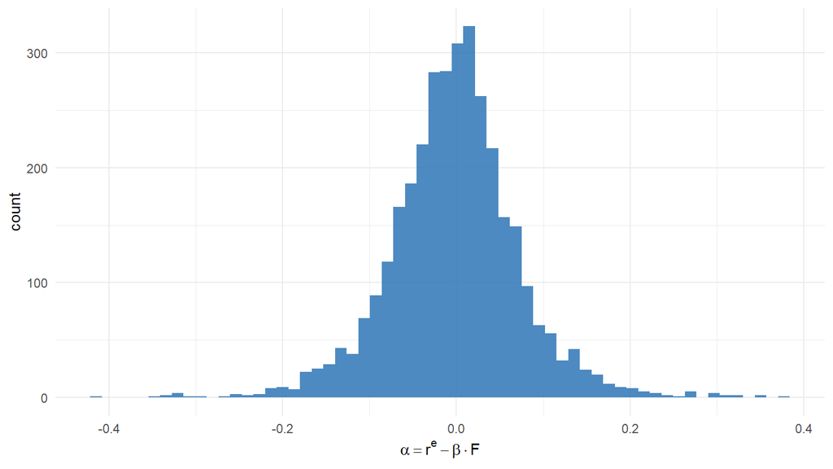

Realised monthly alpha — symmetric around zero, fat-tailed.

```r
feats |>
  filter(!is.na(alpha_realized)) |>
  ggplot(aes(alpha_realized)) +
  geom_histogram(bins = 60, fill = "#2E75B6", alpha = 0.85) +
  labs(x = expression(alpha == r^e - beta %.% F), y = "count")
```

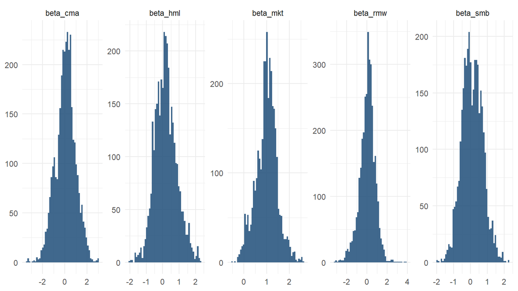

FF5 betas across the panel — mostly market-driven.

```r
feats |>
  filter(!is.na(beta_mkt)) |>
  select(beta_mkt, beta_smb, beta_hml, beta_rmw, beta_cma) |>
  pivot_longer(everything(), names_to = "factor", values_to = "loading") |>
  ggplot(aes(loading)) +
  geom_histogram(bins = 50, fill = "#1F4E79", alpha = 0.85) +
  facet_wrap(~ factor, scales = "free", ncol = 5) +
  labs(x = NULL, y = NULL)
```

# 5. Clustering on return co-movement

K-Means is fit at the end of each year on the prior sixty months; the assignment is applied to all twelve months of the following calendar year.

```r
clust <- build_clusters_annual(panel)
```

```
[18:11:00] Building annual K-Means clusters on return co-movement
[18:11:00]   refit 2017-12-31: k=2, sil=0.425, n=30
[18:11:00]   refit 2018-12-31: k=2, sil=0.504, n=31
[18:11:00]   refit 2019-12-31: k=2, sil=0.460, n=35
[18:11:00]   refit 2020-12-31: k=3, sil=0.469, n=37
[18:11:00]   refit 2021-12-31: k=2, sil=0.438, n=38
[18:11:00]   refit 2022-12-31: k=2, sil=0.411, n=41
[18:11:00]   refit 2023-12-31: k=2, sil=0.403, n=42
```

```r
clust$diag |>
  kable(digits = 3, caption = "Cluster diagnostics by refit date")
```

Cluster diagnostics by refit date

| refit_date | k | silhouette | n_stocks |
| --- | --- | --- | --- |
| 2017-12-31 | 2 | 0.425 | 30 |
| 2018-12-31 | 2 | 0.504 | 31 |
| 2019-12-31 | 2 | 0.460 | 35 |
| 2020-12-31 | 3 | 0.469 | 37 |
| 2021-12-31 | 2 | 0.438 | 38 |
| 2022-12-31 | 2 | 0.411 | 41 |
| 2023-12-31 | 2 | 0.403 | 42 |

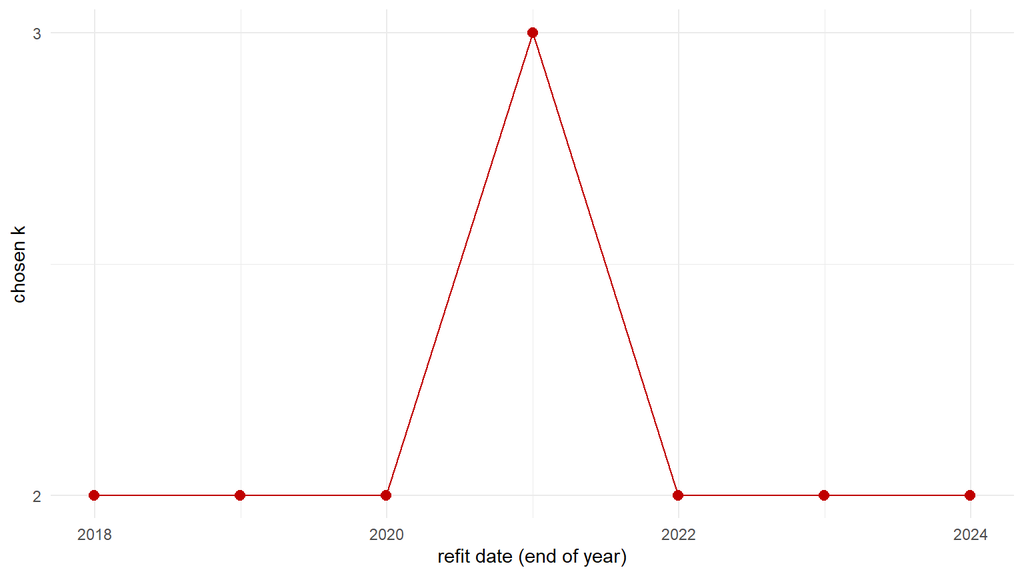

Chosen k by refit year. Stability across refits is encouraging — drift in $k$ would suggest the structure is unstable.

```r
clust$diag |>
  ggplot(aes(refit_date, k)) +
  geom_point(size = 2.5, colour = "#C00000") +
  geom_line(colour = "#C00000") +
  scale_y_continuous(breaks = 2:10) +
  labs(x = "refit date (end of year)", y = "chosen k")
```

# 6. Three-way comparison

```r
feats_g <- attach_clusters(feats, clust$assignments)
```

## 6.1 Composition

How much do the three groupings overlap?

```r
comp <- composition_compare(feats_g)
comp$ari |>
  kable(digits = 3, caption = "Adjusted Rand index between scheme pairs")
```

Adjusted Rand index between scheme pairs

| comparison | adj_rand | n_stocks |
| --- | --- | --- |
| GICS vs FF12 | 0.527 | 42 |
| GICS vs Cluster | 0.034 | 42 |
| FF12 vs Cluster | 0.055 | 42 |

The adjusted Rand index measures partition similarity, with 1 = identical and 0 = random. Values close to zero between GICS or FF12 and the K-Means clusters mean the unsupervised partition is genuinely different from the industry partitions, which is what we’d want — otherwise it adds nothing.

```r
comp$contingency$gics_vs_cluster |>
  as.data.frame.matrix() |>
  kable(caption = "GICS sector × K-Means cluster (most recent month)")
```

GICS sector × K-Means cluster (most recent month)

|  | 1 | 2 |
| --- | --- | --- |
| Communication Services | 3 | 0 |
| Consumer Discretionary | 2 | 0 |
| Consumer Staples | 1 | 1 |
| Energy | 2 | 0 |
| Financials | 5 | 0 |
| Health Care | 1 | 5 |
| Industrials | 5 | 2 |
| Information Technology | 5 | 1 |
| Materials | 2 | 0 |
| Real Estate | 3 | 0 |
| Utilities | 1 | 3 |

```r
comp$contingency$ff12_vs_cluster |>
  as.data.frame.matrix() |>
  kable(caption = "FF12 industry × K-Means cluster (most recent month)")
```

FF12 industry × K-Means cluster (most recent month)

|  | 1 | 2 |
| --- | --- | --- |
| BusEq | 8 | 1 |
| Chems | 1 | 1 |
| Enrgy | 1 | 0 |
| Hlth | 1 | 5 |
| Manuf | 4 | 0 |
| Money | 6 | 0 |
| NoDur | 2 | 0 |
| Other | 3 | 2 |
| Shops | 1 | 0 |
| Telcm | 1 | 0 |
| Utils | 2 | 3 |

## 6.2 Within-group homogeneity

A “good” classification produces internally similar members. We measure this two ways: the cross-sectional standard deviation of realised alpha within each group at each date (lower = more homogeneous in unexplained returns), and the mean pairwise correlation of excess returns among group members (higher = more co-moving).

```r
homo <- homogeneity_compare(feats_g, panel)
homo |> kable(digits = 4, caption = "Within-group homogeneity by scheme")
```

Within-group homogeneity by scheme

| scheme | mean_alpha_sd | median_alpha_sd | mean_within_corr | median_within_corr |
| --- | --- | --- | --- | --- |
| GICS | 0.0627 | 0.0561 | 0.5305 | 0.5003 |
| FF12 | 0.0581 | 0.0529 | 0.3815 | 0.4067 |
| Cluster | 0.0646 | 0.0629 | 0.3053 | 0.2817 |

## 6.3 Predictive accuracy

Per-group Elastic Net regressions predict $\alpha_{i,t+1}$ from the feature set. We report out-of-sample R², MAE, and directional accuracy on the 2023–2024 holdout, weighted by group size.

```r
pred <- prediction_compare(feats_g)
```

```
[18:11:01] Prediction: train n=698, test n=335
```

```r
pred$aggregate |>
  arrange(desc(r2_oos_weighted)) |>
  kable(digits = 4, caption = "Aggregate prediction metrics by scheme")
```

Aggregate prediction metrics by scheme

| scheme | n_test_total | r2_oos_weighted | mae_weighted | dir_acc_weighted | n_groups |
| --- | --- | --- | --- | --- | --- |
| Pooled | 335 | -0.0223 | 0.0591 | 0.4925 | 1 |
| Cluster | 332 | -0.0445 | 0.0584 | 0.5181 | 2 |
| FF12 | 279 | -0.6144 | 0.0650 | 0.4552 | 6 |
| GICS | 223 | -1.0609 | 0.0710 | 0.5202 | 5 |

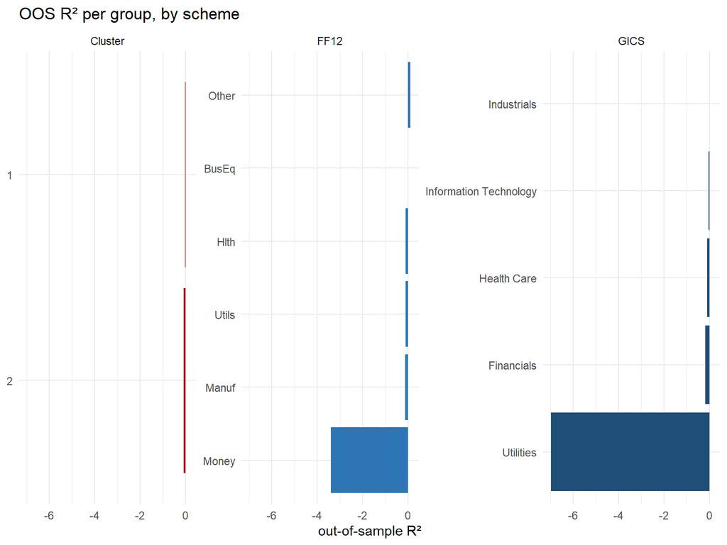

```r
pred$per_group |>
  ggplot(aes(reorder(group, r2_oos), r2_oos, fill = scheme)) +
  geom_col() +
  coord_flip() +
  facet_wrap(~ scheme, scales = "free_y") +
  labs(x = NULL, y = "out-of-sample R²", fill = NULL,
       title = "OOS R² per group, by scheme") +
  scale_fill_manual(values = c(GICS = "#1F4E79", FF12 = "#2E75B6", Cluster = "#C00000")) +
  theme(legend.position = "none")
```

The pooled baseline (no grouping) gives a single all-stocks Elastic Net. If any of the three schemes can beat the pooled model on R² *and* directional accuracy, that scheme is adding information beyond what the features carry on their own.

## 6.4 Anomaly detection

Isolation Forest is trained per group on the train window and scored on the holdout; the most anomalous five percent are flagged. We then look at average forward alpha at one, three, and six months for flagged versus non-flagged stocks.

```r
anom <- anomaly_compare(feats_g)
```

```
[18:11:02]   iForest within GICS
[18:11:02]   iForest within FF12
[18:11:02]   iForest within Cluster
```

```r
anom$fwd_compare |>
  arrange(scheme, horizon, flagged) |>
  kable(digits = 4,
        caption = "Mean forward alpha for flagged vs. non-flagged stocks, by scheme and horizon")
```

Mean forward alpha for flagged vs. non-flagged stocks, by scheme and horizon

| scheme | flagged | horizon | n | mean_fwd_alpha | median_fwd_alpha |
| --- | --- | --- | --- | --- | --- |
| Cluster | FALSE | 1 | 315 | -0.0068 | -0.0077 |
| Cluster | TRUE | 1 | 17 | -0.0081 | 0.0066 |
| Cluster | FALSE | 3 | 273 | -0.0020 | 0.0021 |
| Cluster | TRUE | 3 | 17 | 0.0003 | 0.0018 |
| Cluster | FALSE | 6 | 232 | -0.0017 | 0.0019 |
| Cluster | TRUE | 6 | 16 | -0.0129 | -0.0232 |
| FF12 | FALSE | 1 | 293 | -0.0087 | -0.0077 |
| FF12 | TRUE | 1 | 18 | 0.0034 | -0.0177 |
| FF12 | FALSE | 3 | 254 | -0.0032 | 0.0037 |
| FF12 | TRUE | 3 | 17 | 0.0158 | -0.0047 |
| FF12 | FALSE | 6 | 216 | -0.0034 | 0.0019 |
| FF12 | TRUE | 6 | 16 | -0.0018 | 0.0026 |
| GICS | FALSE | 1 | 314 | -0.0064 | -0.0069 |
| GICS | TRUE | 1 | 21 | -0.0246 | -0.0213 |
| GICS | FALSE | 3 | 274 | -0.0015 | 0.0035 |
| GICS | TRUE | 3 | 18 | -0.0162 | -0.0083 |
| GICS | FALSE | 6 | 232 | -0.0014 | 0.0018 |
| GICS | TRUE | 6 | 18 | -0.0251 | -0.0202 |

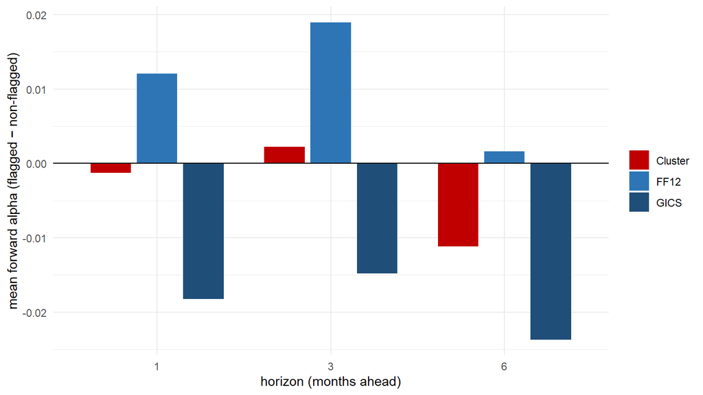

Forward alpha gap (flagged minus non-flagged) by horizon. A negative bar at +1m would suggest flagged stocks subsequently underperform on a risk-adjusted basis — the mispricing reading.

```r
anom$fwd_compare |>
  group_by(scheme, horizon) |>
  summarise(
    gap = mean_fwd_alpha[flagged] - mean_fwd_alpha[!flagged],
    .groups = "drop"
  ) |>
  ggplot(aes(factor(horizon), gap, fill = scheme)) +
  geom_col(position = position_dodge(width = 0.8), width = 0.7) +
  geom_hline(yintercept = 0) +
  scale_fill_manual(values = c(GICS = "#1F4E79", FF12 = "#2E75B6", Cluster = "#C00000")) +
  labs(x = "horizon (months ahead)",
       y = "mean forward alpha (flagged − non-flagged)", fill = NULL)
```

```r
anom$flag_overlap |>
  filter(a != b) |>
  kable(digits = 3,
        caption = "Pairwise Jaccard overlap of flagged (permno, date_eom) keys")
```

Pairwise Jaccard overlap of flagged (permno, date_eom) keys

| a | b | n_a | n_b | jaccard |
| --- | --- | --- | --- | --- |
| GICS | FF12 | 21 | 18 | 0.300 |
| GICS | Cluster | 21 | 17 | 0.086 |
| FF12 | GICS | 18 | 21 | 0.300 |
| FF12 | Cluster | 18 | 17 | 0.167 |
| Cluster | GICS | 17 | 21 | 0.086 |
| Cluster | FF12 | 17 | 18 | 0.167 |

# 7. Discussion

The four-dimensional comparison gives a more complete answer than any single metric:

Two caveats. First, the dev-mode subset of fifty stocks limits how much weight the numbers can bear; a full S&P 500 run is necessary before treating these comparisons as decisive. Second, the alpha computation is itself dependent on the FF5 specification — alpha that the FF5 model fails to absorb might still be priced by extensions (momentum, quality, short-term reversal). Our anomaly definition is “FF5-residual,” not “genuinely unexplained.”

# 8. Limitations and next steps

- **Universe size.** Final numbers should come from `CFG$dev_mode <- FALSE` on the full universe, not the 50-stock sample.
- **Cluster stability.** The annual-refit + Hungarian-matching pipeline keeps cluster IDs stable but doesn’t guarantee that the underlying groupings are stable. A robustness check that varies the refit window (say, 36 vs. 60 vs. 84 months) would be useful.
- **Alternative anomaly horizons.** Six months is the longest forward horizon we report. Some mispricing-reversion stories play out over a year or longer; extending the horizon would test those.
- **Sector-conditional clustering.** A natural follow-up is K-Means *within* GICS sectors — does sub-sectoral clustering find structure that flat clustering misses?

# Outputs

```r
list.files(c(PATHS$raw, PATHS$processed),
           pattern = "\\.parquet$", full.names = TRUE) |>
  tibble(file = _) |>
  mutate(size_kb = round(file.size(file) / 1024, 1)) |>
  kable()
```

| file | size_kb |
| --- | --- |
| data/processed/clusters_annual.parquet | 2.4 |
| data/processed/clusters_diag.parquet | 1.4 |
| data/processed/features.parquet | 841.0 |
| data/processed/panel.parquet | 278.0 |
| data/raw/ccm_gics.parquet | 13.6 |
| data/raw/crsp_msf.parquet | 1106.8 |
| data/raw/crsp_sic_history.parquet | 6.3 |
| data/raw/crsp_stocknames.parquet | 17.9 |
| data/raw/ff12_def.parquet | 3.0 |
| data/raw/ff5.parquet | 26.6 |
| data/raw/fred_dff.parquet | 184.1 |
| data/raw/fred_dgs10.parquet | 125.3 |
| data/raw/fred_vixcls.parquet | 79.0 |
| data/raw/sp500_members.parquet | 9.6 |